# Stat 369 Lab 6: Autism trees

Anish Hota

This lab looks at data collected to try to detect autism spectrum disorder (ASD) biochemically. (note: remove the non-biochemical variable).

We use trees to detect ASD.

Submit a knitted html or pdf of your answer to Canvas.

## Tasks

0. Note you need to be careful when reading in the data - have a look at the file before you read it in and figure out how to read it without manually changing the file.

```r
df <- read_csv("S1Dataset.csv")
clean_df <- df |>
  mutate(across(everything(), ~ suppressWarnings(as.numeric(.x)))) |>
  mutate(Group = df$Group)
features <- c("SAM/SAH","% DNA methylation","fGSH/GSSG","tGSH/GSSG",
"fCystine/fCysteine","% oxidized", "Vineland ABC")
train_df <- df %>%
  mutate(across(where(is.character), ~na_if(.x, ""))) |>
  mutate(across(!Group, as.numeric)) |>
  filter(Group %in% c("ASD","NEU")) |>
  mutate(Group = factor(Group)) |>
  select(Group, any_of(features))
```

1. Use `rpart()` to grow a tree that distinguishes the ASD and NEU groups, and give the confusion matrix and the proportion of people (from these two groups) correctly classified. Plot the tree (showing labels – make sure you set the margin in the plot call to make room for the labels).

```r
fit1 <- rpart(Group ~ ., data=train_df, method="class")
pred1 <- predict(fit1, type="class")
results1 <- tibble(True = train_df$Group, Pred = pred1)
conf1 <- table(results1)
conf1
```

```
##      Pred
## True  ASD NEU
##   ASD  80   3
##   NEU   9  67
```

```r
mean(results1$True == results1$Pred)
```

```
## [1] 0.9245283
```

```r
results1 |>
  group_by(True) |>
  summarise(acc = mean(True==Pred))
```

```
## # A tibble: 2 × 2
##   True    acc
##   <fct> <dbl>
## 1 ASD   0.964
## 2 NEU   0.882
```

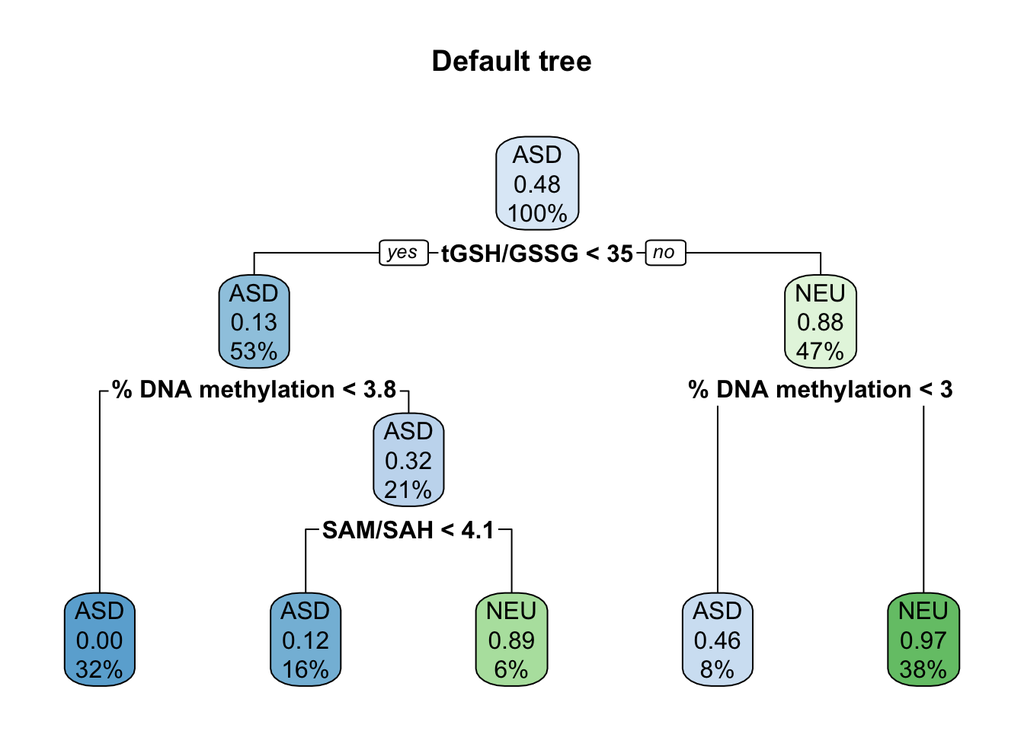

```r
rpart.plot(fit1, main="Default tree")
```

2. The dataset makes the classifier look good, because the number of ASD and neurotypical participants are equal. In reality, ASD affects about 1.5% of people. Run `rpart()` with the prior argument (see the help page), to build a tree based on population prior probabilities of 0.015 and 0.985. Report the confusion matrix and the proportion of ASD and NEU groups correctly classified. Plot the tree.

```r
fit2 <- rpart(Group ~ ., data=train_df, method="class",
parms=list(prior=c(0.015, 0.985)))
pred2 <- predict(fit2, type="class")
results2 <- tibble(True = train_df$Group, Pred = pred2)
table(results2)
```

```
##      Pred
## True  ASD NEU
##   ASD  66  17
##   NEU   0  76
```

```r
mean(results2$True == results2$Pred)
```

```
## [1] 0.8930818
```

```r
results2 |>
  group_by(True) |>
  summarise(acc = mean(True==Pred))
```

```
## # A tibble: 2 × 2
##   True    acc
##   <fct> <dbl>
## 1 ASD   0.795
## 2 NEU   1
```

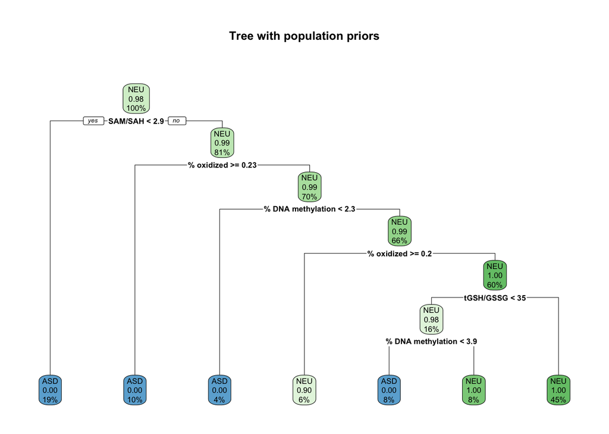

```r
rpart.plot(fit2, main="Tree with population priors")
```

3. Suppose that false negative classifications (missing ASD) are thought to be more important than false positive (suspecting ASD). Run `rpart()` with the `prior` argument as in the previous question and also with the `loss` argument saying that false negatives are 10 times as bad as false positives. Report the confusion matrix and the proportion of ASD and NEU groups correctly classified. Plot the tree. Did you get the result you expected?

```r
lossmat <- matrix(c(0,10, 1,0), nrow=2)
fit3a <- rpart(Group ~ ., data=train_df, method="class",
parms=list(prior=c(0.015,0.985), loss=lossmat))
pred3a <- predict(fit3a, type="class")
results3a <- tibble(True = train_df$Group, Pred = pred3a)
table(results3a)
```

```
##      Pred
## True  ASD NEU
##   ASD  66  17
##   NEU   0  76
```

```r
mean(results3a$True == results3a$Pred)
```

```
## [1] 0.8930818
```

```r
results3a |>
  group_by(True) |>
  summarise(acc = mean(True==Pred))
```

```
## # A tibble: 2 × 2
##   True    acc
##   <fct> <dbl>
## 1 ASD   0.795
## 2 NEU   1
```

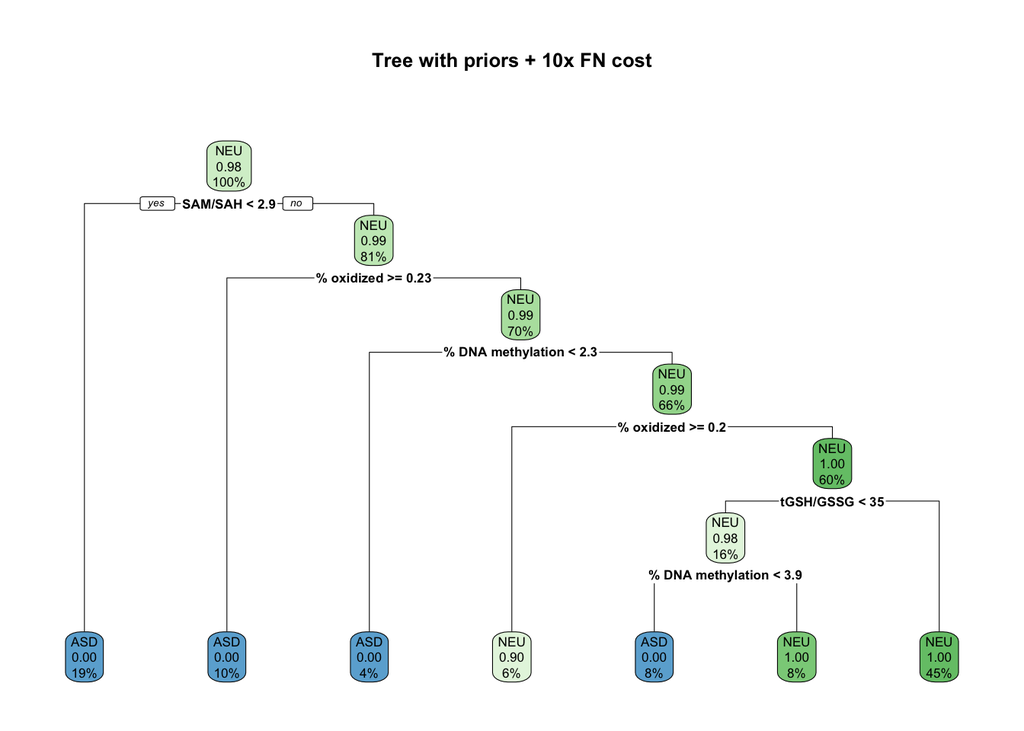

```r
rpart.plot(fit3a, main="Tree with priors + 10x FN cost")
```

Now do the same except set the penalty for false negatives to 100 times.

```r
lossmat100 <- matrix(c(0,100, 1,0), nrow=2)
fit3b <- rpart(Group ~ ., data=train_df, method="class",
parms=list(prior=c(0.015,0.985), loss=lossmat100))
pred3b <- predict(fit3b, type="class")
results3b <- tibble(True = train_df$Group, Pred = pred3b)
table(results3b)
```

```
##      Pred
## True  ASD NEU
##   ASD  66  17
##   NEU   0  76
```

```r
mean(results3b$True == results3b$Pred)
```

```
## [1] 0.8930818
```

```r
results3b %>% group_by(True) %>% summarise(acc = mean(True==Pred))
```

```
## # A tibble: 2 × 2
##   True    acc
##   <fct> <dbl>
## 1 ASD   0.795
## 2 NEU   1
```

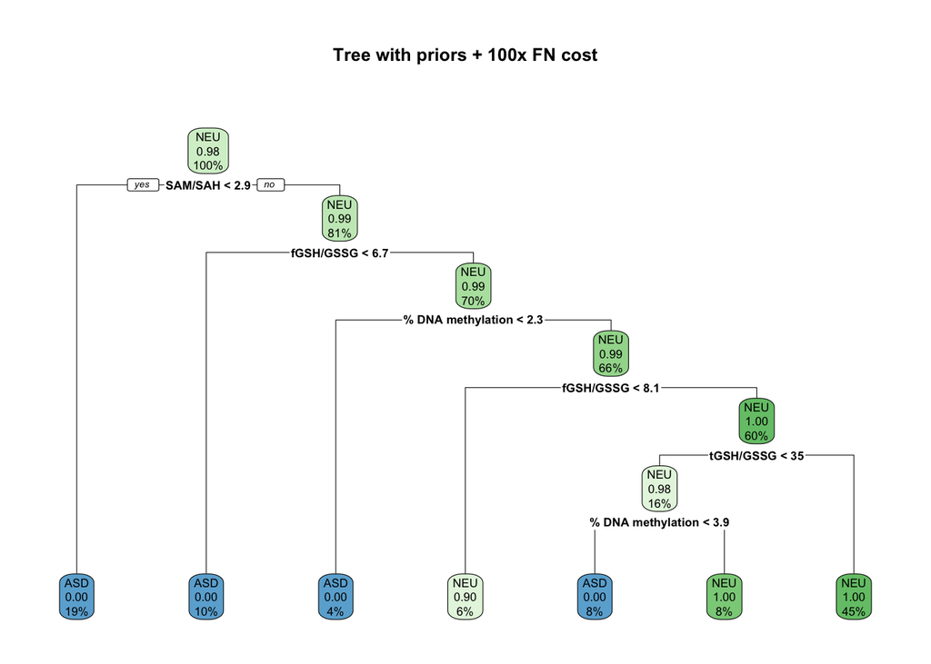

```r
rpart.plot(fit3b, main="Tree with priors + 100x FN cost")
```

4. Use this final tree to predict for the SIB group (all of whom are actually neurotypical). What proportion are correctly classified?

```r
sib_df <- clean_df |>
  filter(Group=="SIB") |>
  select(all_of(features))
pred_sib <- predict(fit3b, newdata=sib_df, type="class")
mean(pred_sib=="NEU")
```

```
## [1] 0.8085106
```

About 80.85% were correctly classified as NEU to be the final tree.

## Citations and Acknowledgments

Used ChatGPT to help out with reading the data in part 0.